# Notebook 24 – Solutions

## Getting Started

Before running this notebook, select “Session > Restart R and Clear Output” in the menu above to start a new R session. This will clear any old data sets and give us a blank slate to start with.

## Flights

### Datasets

In this notebook we are going to look at a relatively well-known data set of domestic flights leaving from the three major NYC airports in the year 2013. There are a few datasets. First, a dataset of the flights themselves. Note that all of the times are in local time (including arrival hour) and the departure and arrival delays are in seconds.

```r
flights <- read_csv("data/flights.csv")
flights
```

```
## # A tibble: 318,903 × 13
##    origin dest   year month   day dep_hour dep_min dep_delay arr_hour arr_min
##    <chr>  <chr> <dbl> <dbl> <dbl>    <dbl>   <dbl>     <dbl>    <dbl>   <dbl>
##  1 EWR    IAH    2013     1     1        5      17       120        8      30
##  2 LGA    IAH    2013     1     1        5      33       240        8      50
##  3 JFK    MIA    2013     1     1        5      42       120        9      23
##  4 JFK    BQN    2013     1     1        5      44       -60       10       4
##  5 LGA    ATL    2013     1     1        5      54      -360        8      12
##  6 EWR    ORD    2013     1     1        5      54      -240        7      40
##  7 EWR    FLL    2013     1     1        5      55      -300        9      13
##  8 LGA    IAD    2013     1     1        5      57      -180        7       9
##  9 JFK    MCO    2013     1     1        5      57      -180        8      38
## 10 LGA    ORD    2013     1     1        5      58      -120        7      53
## # … with 318,893 more rows, and 3 more variables: arr_delay <dbl>, carrier <chr>,
## #   tailnum <chr>
```

We also have a data set of weather for each hour of the year at the three airports.

```r
weather <- read_csv("data/weather.csv") %>%
  mutate(time_hour = force_tz(time_hour, tzone = "America/New_York"))
weather
```

```
## # A tibble: 26,110 × 5
##    origin time_hour            temp wind_speed visib
##    <chr>  <dttm>              <dbl>      <dbl> <dbl>
##  1 EWR    2013-01-01 06:00:00  39.0      10.4     10
##  2 EWR    2013-01-01 07:00:00  39.0       8.06    10
##  3 EWR    2013-01-01 08:00:00  39.0      11.5     10
##  4 EWR    2013-01-01 09:00:00  39.9      12.7     10
##  5 EWR    2013-01-01 10:00:00  39.0      12.7     10
##  6 EWR    2013-01-01 11:00:00  37.9      11.5     10
##  7 EWR    2013-01-01 12:00:00  39.0      15.0     10
##  8 EWR    2013-01-01 13:00:00  39.9      10.4     10
##  9 EWR    2013-01-01 14:00:00  39.9      15.0     10
## 10 EWR    2013-01-01 15:00:00  41        13.8     10
## # … with 26,100 more rows
```

We also have a data set of the airports. These include the time zone of the airport as well as the location as longitude and latitude. We’ll use a semi join to remove small airports that are not in our collection.

```r
airports <- read_csv("data/airports.csv") %>%
  semi_join(flights, by = c("faa" = "dest"))
airports
```

```
## # A tibble: 98 × 5
##    faa   name                                 lon   lat tzone
##    <chr> <chr>                              <dbl> <dbl> <chr>
##  1 ABQ   Albuquerque International Sunport -107.   35.0 America/Denver
##  2 ACK   Nantucket Mem                      -70.1  41.3 America/New_York
##  3 ALB   Albany Intl                        -73.8  42.7 America/New_York
##  4 ATL   Hartsfield Jackson Atlanta Intl    -84.4  33.6 America/New_York
##  5 AUS   Austin Bergstrom Intl              -97.7  30.2 America/Chicago
##  6 AVL   Asheville Regional Airport         -82.5  35.4 America/New_York
##  7 BDL   Bradley Intl                       -72.7  41.9 America/New_York
##  8 BGR   Bangor Intl                        -68.8  44.8 America/New_York
##  9 BHM   Birmingham Intl                    -86.8  33.6 America/Chicago
## 10 BNA   Nashville Intl                     -86.7  36.1 America/Chicago
## # … with 88 more rows
```

Finally, we will also use the state polygons to create a few spatial plots.

```r
state <- read_sf("data/state.geojson") %>%
  filter(!(abb %in% c("AK", "HI")))
```

I have already removed the fligths to Alaska and Hawaii, so I also removed them above from the state polygons.

### Some Exploratory Analysis

As a warm-up, group the data by the destination airport and compute the number of flights to each destination. Arrange the data in descending count.

```r
flights %>%
  group_by(dest) %>%
  summarize(n = n()) %>%
  arrange(desc(n))
```

```
## # A tibble: 102 × 2
##    dest      n
##    <chr> <int>
##  1 ATL   16673
##  2 ORD   16482
##  3 LAX   15287
##  4 BOS   14739
##  5 CLT   13559
##  6 MCO   13464
##  7 SFO   12857
##  8 MIA   11482
##  9 FLL   11224
## 10 DCA    9025
## # … with 92 more rows
```

Now, create a spatial plot that shows the location of each airport overlaid over the state boundaries. Scale the sizes of the airports relative to the number of flights. Transform the coordinate system to one with crs equal to 5069.

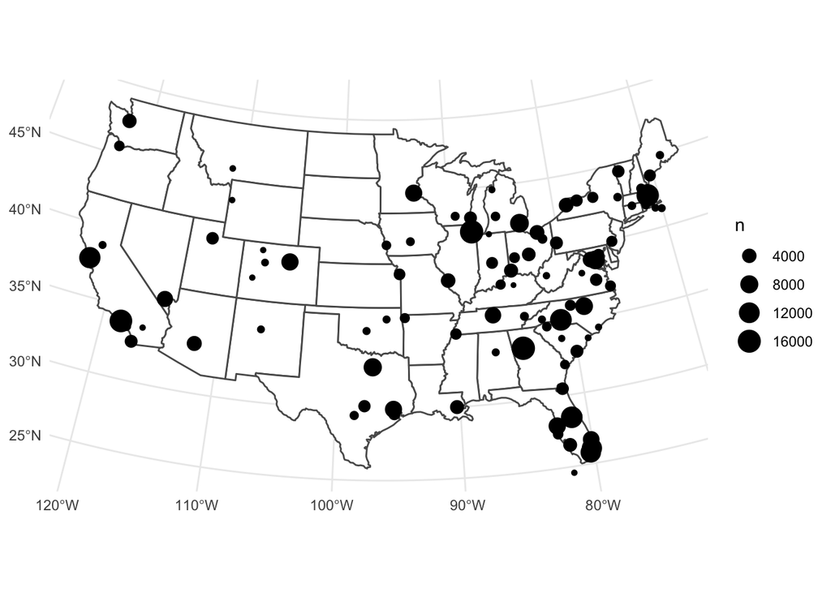

```r
flights %>%
  group_by(dest) %>%
  summarize(n = n()) %>%
  inner_join(airports, by = c("dest" = "faa")) %>%
  st_as_sf(coords = c("lon", "lat"), crs = 4326, remove = FALSE) %>%
  st_transform(5069) %>%
  ggplot() +
    geom_sf(data = state, fill = "white") +
    geom_sf(aes(size = n))
```

### Departure Time

Now, create a column `dep_time` using the `make_datetime` function from the departure time variables. Use the function `force_tz` and the time zone “America/New_York” to tell R that these are in local NYC time rather than UTC. Once you get the answer, store the results in the `flights` data.

```r
flights <- flights %>%
  mutate(dep_time = make_datetime(year, month, day, dep_hour, dep_min)) %>%
  mutate(dep_time = force_tz(dep_time, tzone = "America/New_York"))
```

Now, compute the weekday of each flight, group by the weekday, and summarize the percentage of flights on each weekday that are at least 1 hour late departing.

```r
flights %>%
  mutate(wday = wday(dep_time, label = TRUE)) %>%
  group_by(wday) %>%
  summarize(dep_delay = mean(dep_delay > 60 * 60) * 100)
```

```
## # A tibble: 7 × 2
##   wday  dep_delay
##   <ord>     <dbl>
## 1 Mon        8.58
## 2 Tue        6.70
## 3 Wed        6.76
## 4 Thu        8.97
## 5 Fri        8.26
## 6 Sat        4.71
## 7 Sun        6.29
```

### Weather

We want to join the flights data to the weather data set, group by the variable `visib` (the visibility in miles), and compute the percentage of flights that are at least 15 minutes late. Plot the results as a line plot with visib on the x-axis and the percentage on the y-axis.

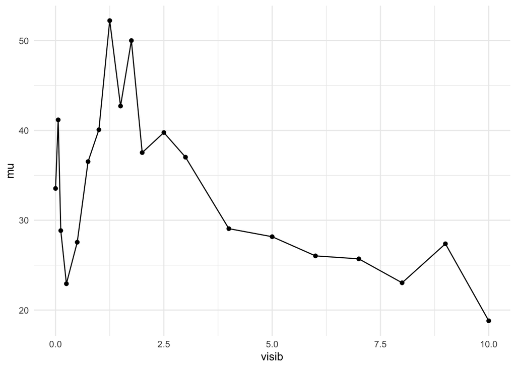

```r
flights %>%
  mutate(time_hour = floor_date(dep_time, "hour")) %>%
  inner_join(weather, by = c("origin", "time_hour")) %>%
  group_by(visib) %>%
  summarize(mu = mean(dep_delay > 15 * 60) * 100) %>%
  ggplot(aes(visib, mu)) +
    geom_point() +
    geom_line()
```

Repeat the prior question with the wind speed in place of the visibility (you may want to filter to only include wind speeds under 50 mph.)

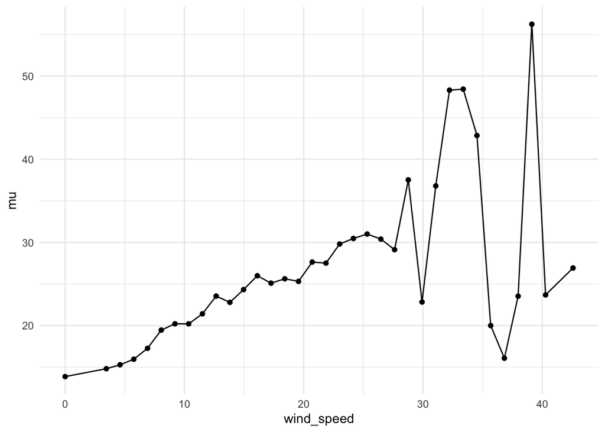

```r
flights %>%
  mutate(time_hour = floor_date(dep_time, "hour")) %>%
  inner_join(weather, by = c("origin", "time_hour")) %>%
  group_by(wind_speed) %>%
  filter(wind_speed < 200) %>%
  summarize(mu = mean(dep_delay > 15 * 60) * 100) %>%
  ggplot(aes(wind_speed, mu)) +
    geom_point() +
    geom_line()
```

### Arrival Time

We now want to create a column `arr_time` as we did above. The arrival times are also all local, but are in different time zones. In the code below, join `flights` to `airports`, create `arr_time` and then use the function `force_tzs` to convert all of the time zones into “America/New_York”.

```r
flights <- flights %>%
  inner_join(airports, by = c("dest" = "faa")) %>%
  mutate(arr_time = make_datetime(year, month, day, arr_hour, arr_min)) %>%
  mutate(arr_time = force_tzs(arr_time, tzones = tzone, tzone_out = "America/New_York"))

flights
```

```
## # A tibble: 312,089 × 19
##    origin dest   year month   day dep_hour dep_min dep_delay arr_hour arr_min
##    <chr>  <chr> <dbl> <dbl> <dbl>    <dbl>   <dbl>     <dbl>    <dbl>   <dbl>
##  1 EWR    IAH    2013     1     1        5      17       120        8      30
##  2 LGA    IAH    2013     1     1        5      33       240        8      50
##  3 JFK    MIA    2013     1     1        5      42       120        9      23
##  4 LGA    ATL    2013     1     1        5      54      -360        8      12
##  5 EWR    ORD    2013     1     1        5      54      -240        7      40
##  6 EWR    FLL    2013     1     1        5      55      -300        9      13
##  7 LGA    IAD    2013     1     1        5      57      -180        7       9
##  8 JFK    MCO    2013     1     1        5      57      -180        8      38
##  9 LGA    ORD    2013     1     1        5      58      -120        7      53
## 10 JFK    PBI    2013     1     1        5      58      -120        8      49
## # … with 312,079 more rows, and 9 more variables: arr_delay <dbl>, carrier <chr>,
## #   tailnum <chr>, dep_time <dttm>, name <chr>, lon <dbl>, lat <dbl>, tzone <chr>,
## #   arr_time <dttm>
```

You may need the help page for `force_tzs` to figure out the syntax. Once you are happy with the code, save the data back into the variable `flights`.

### Flight Time

Compute the difference between `arr_time` and `dep_time`. Filter the rows where this difference is negative. There should be a few thousand rows. Look at the data and try to figure out the problem(s).

```r
flights %>%
  mutate(tdiff = arr_time - dep_time) %>%
  filter(tdiff < 0)
```

```
## # A tibble: 2,410 × 20
##    origin dest   year month   day dep_hour dep_min dep_delay arr_hour arr_min
##    <chr>  <chr> <dbl> <dbl> <dbl>    <dbl>   <dbl>     <dbl>    <dbl>   <dbl>
##  1 JFK    TPA    2013     1     1       22      17      2820        1      40
##  2 JFK    FLL    2013     1     1       22      29      1800        1      49
##  3 JFK    LAS    2013     1     1       23      26      6960        1      31
##  4 EWR    MCI    2013     1     1       23      43     22740        3      14
##  5 EWR    FLL    2013     1     2       21      45         0        1      11
##  6 JFK    FLL    2013     1     2       22      15      -300        1      42
##  7 EWR    OKC    2013     1     2       22      25     10500        2      31
##  8 LGA    ATL    2013     1     2       22      59      7140        1      22
##  9 JFK    MCO    2013     1     2       23      37      6120        2      22
## 10 JFK    PBI    2013     1     3       22      20      2100        1       3
## # … with 2,400 more rows, and 10 more variables: arr_delay <dbl>, carrier <chr>,
## #   tailnum <chr>, dep_time <dttm>, name <chr>, lon <dbl>, lat <dbl>, tzone <chr>,
## #   arr_time <dttm>, tdiff <drtn>
```

Update the `flights` data by adding `24 * 60 * 60` seconds to any row where the arrival time is less than the departure time. This should fix most of the errors you found above.

```r
flights <- flights %>%
  mutate(arr_time = if_else(arr_time < dep_time, arr_time + 24 * 60 * 60, arr_time))

flights
```

```
## # A tibble: 312,089 × 19
##    origin dest   year month   day dep_hour dep_min dep_delay arr_hour arr_min
##    <chr>  <chr> <dbl> <dbl> <dbl>    <dbl>   <dbl>     <dbl>    <dbl>   <dbl>
##  1 EWR    IAH    2013     1     1        5      17       120        8      30
##  2 LGA    IAH    2013     1     1        5      33       240        8      50
##  3 JFK    MIA    2013     1     1        5      42       120        9      23
##  4 LGA    ATL    2013     1     1        5      54      -360        8      12
##  5 EWR    ORD    2013     1     1        5      54      -240        7      40
##  6 EWR    FLL    2013     1     1        5      55      -300        9      13
##  7 LGA    IAD    2013     1     1        5      57      -180        7       9
##  8 JFK    MCO    2013     1     1        5      57      -180        8      38
##  9 LGA    ORD    2013     1     1        5      58      -120        7      53
## 10 JFK    PBI    2013     1     1        5      58      -120        8      49
## # … with 312,079 more rows, and 9 more variables: arr_delay <dbl>, carrier <chr>,
## #   tailnum <chr>, dep_time <dttm>, name <chr>, lon <dbl>, lat <dbl>, tzone <chr>,
## #   arr_time <dttm>
```

```r
flights %>%
  mutate(tdiff = arr_time - dep_time) %>%
  group_by(dest) %>%
  summarize(avg = mean(tdiff)) %>%
  arrange(avg) %>%
  inner_join(airports, by = c("dest" = "faa"))
```

```
## # A tibble: 98 × 6
##    dest  avg           name                                   lon   lat tzone
##    <chr> <drtn>        <chr>                                <dbl> <dbl> <chr>
##  1 BDL   48.71642 mins "Bradley Intl"                       -72.7  41.9 America/New_…
##  2 ALB   55.82850 mins "Albany Intl"                        -73.8  42.7 America/New_…
##  3 PVD   55.86047 mins "Theodore Francis Green State"       -71.4  41.7 America/New_…
##  4 MHT   63.94085 mins "Manchester Regional Airport"        -71.4  42.9 America/New_…
##  5 MVY   64.35714 mins "Martha\\\\'s Vineyard"              -70.6  41.4 America/New_…
##  6 ACK   64.69318 mins "Nantucket Mem"                      -70.1  41.3 America/New_…
##  7 BOS   68.55675 mins "General Edward Lawrence Logan Intl" -71.0  42.4 America/New_…
##  8 SYR   69.77670 mins "Syracuse Hancock Intl"              -76.1  43.1 America/New_…
##  9 PHL   69.85872 mins "Philadelphia Intl"                  -75.2  39.9 America/New_…
## 10 BWI   70.46935 mins "Baltimore Washington Intl"          -76.7  39.2 America/New_…
## # … with 88 more rows
```

Take the data you created above and make a spatial plot similar to the first one. However, this time we want to color the points according to the average flight time from NYC. Use the following color scale:

scale_color_distiller(palette = “Spectral”, guide = “legend”, n.breaks = 10)

Take a moment to adjust the plot to make it look nice. Perhaps set pch = 21?

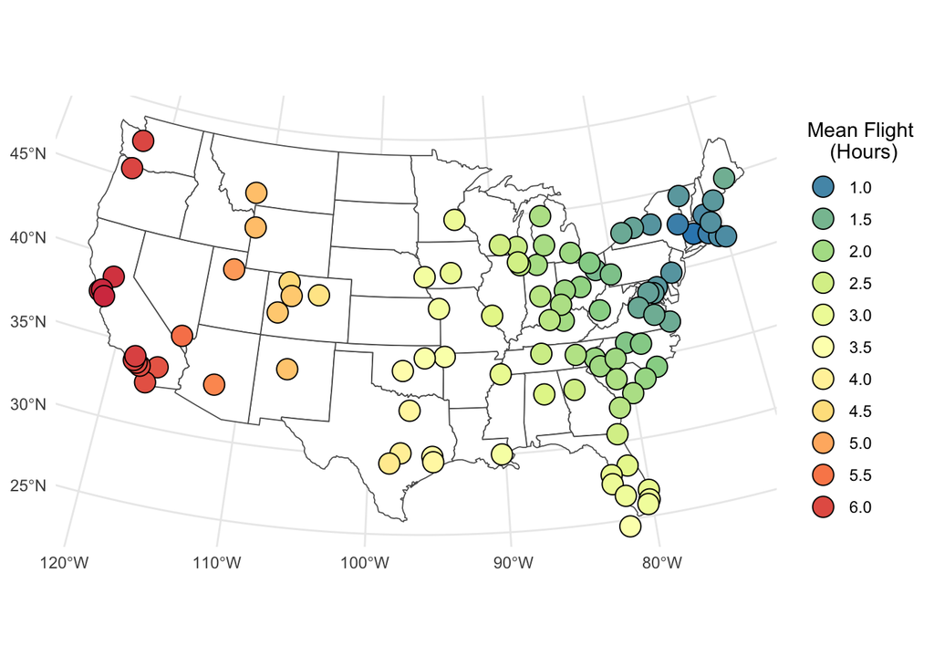

```r
flights %>%
  mutate(tdiff = arr_time - dep_time) %>%
  group_by(dest) %>%
  summarize(avg = as.numeric(mean(tdiff, na.rm = TRUE)) / 60) %>%
  arrange(avg) %>%
  inner_join(airports, by = c("dest" = "faa")) %>%
  st_as_sf(coords = c("lon", "lat"), crs = 4326, remove = FALSE) %>%
  st_transform(5069) %>%
  filter(avg < 7) %>%
  ggplot() +
    geom_sf(data = filter(state, !(abb %in% c("AK", "HI"))), fill = "white", size = 0.3) +
    geom_sf(aes(fill = avg), size = 5, color = "black", pch = 21) +
    scale_fill_distiller(
      palette = "Spectral", guide = "legend", n.breaks = 10
    ) +
    labs(fill = "Mean Flight\n    (Hours)")
```